# data exploration

```r
library(tidyverse)
library(janitor)
library(lubridate)
```

# What’s in data

## Geography codes

How to filter for Borders

```r
geography_codes <- read_csv("../data/raw_data/geography_codes_and_labels_hb2014_01042019.csv") %>%
  clean_names()
```

```r
hb_borders <- geography_codes %>%
  filter(hb_name == "NHS Borders") %>%
  pull(hb)

hb_borders
```

```
[1] "S08000016"
```

HB code 16 - use pulled value as variable.

## Understand incidence data

```r
# 1997 - 2021 annual data
incidence_hb <- read_csv("../data/raw_data/incidence_1997_2021_hb.csv") %>%
  clean_names()
incidence_scot <- read_csv("../data/raw_data/incidence_1997_2021_scotland.csv") %>%
  clean_names()
incidence_network <- read_csv("../data/raw_data/incidence_1997_2021_region.csv") %>%
  clean_names()
# 2017 - 2021 combined 5-yr data
comb_5yr_incidence_hb <- read_csv("../data/raw_data/incidence_5yr_comb_hb.csv") %>%
  clean_names()
comb_5yr_incidence_scot <- read_csv("../data/raw_data/incidence_5yr_comb_scotland.csv") %>%
  clean_names()
comb_5yr_incidence_network <- read_csv("../data/raw_data/incidence_5yr_comb_region.csv") %>%
  clean_names()
```

### understand regions

```r
incidence_network %>%
  distinct(region)
```

| region |
| --- |
| North of Scotland |
| South East of Scotland |
| West of Scotland |

What are the networks? See https://www.nss.nhs.scot/specialist-healthcare/national-networks/what-are-national-networks/cancer-networks/

Which hbs are in which network? Which network contains Borders hb?

- Not in west: https://www.woscan.scot.nhs.uk/
- In **South East (SCAN)**: “SCAN brings together cancer professionals from four NHS Boards: NHS Borders, Dumfries & Galloway, Fife and NHS Lothian, which hosts the Cancer Centre to work together. The aim is to ensure equitable provision of high quality, clinically effective, patient-centred cancer services for a population of approximately 1.5m people.” https://www.scan.scot.nhs.uk/about-us/.

What are their business needs?

- Project has looked at modelling capacity and resource: https://www.scan.scot.nhs.uk/projects/regional-sact-capacity-modelling-tool/
- performance / progress updates are via types of cancer specialties, eg 2017-2019 annual report https://www.scan.scot.nhs.uk/wp-content/uploads/2020/09/SCAN-Annual-Report-2017-2019-Final.pdf

### understand variables

see indicators defined at https://www.isdscotland.org/Health-Topics/Cancer/FAQ/

Incidence:

```
"Incidence is the total number of new cases (registrations) of the cancer diagnosed in Scotland for the given period."
```

Note different from prevalence:

```
"Cancer prevalence is a measure of the burden of cancer in a population at a particular point in time. One-year prevalence is the number of patients diagnosed in the previous year who are still alive; 20-year prevalence is the number of patients diagnosed in the previous 20 years who are still alive…
```

```r
colnames(incidence_hb)
```

```
 [1] "hb"                                       "cancer_site_icd10code"
 [3] "cancer_site"                              "sex"
 [5] "sex_qf"                                   "year"
 [7] "incidences_all_ages"                      "crude_rate"
 [9] "crude_rate_lower95pc_confidence_interval" "crude_rate_upper95pc_confidence_interval"
[11] "easr"                                     "easr_lower95pc_confidence_interval"
[13] "easr_lower95pc_confidence_interval_qf"    "easr_upper95pc_confidence_interval"
[15] "easr_upper95pc_confidence_interval_qf"    "wasr"
[17] "wasr_lower95pc_confidence_interval"       "wasr_lower95pc_confidence_interval_qf"
[19] "wasr_upper95pc_confidence_interval"       "wasr_upper95pc_confidence_interval_qf"
[21] "standardised_incidence_ratio"             "sir_lower95pc_confidence_interval"
[23] "sir_upper95pc_confidence_interval"
```

#### incidence rate variables

Defined in data dictionary for each dataset (scroll down): https://www.opendata.nhs.scot/dataset/annual-cancer-incidence/resource/3aef16b7-8af6-4ce0-a90b-8a29d6870014

- crude_rate: “The crude rate is calculated per 100,000 person-years at risk”
- easr: “The European age-standardised (using the 2013 European Standard Population) incidence rate per 100,000 person-years at risk”
- wasr: “The World age-standardised incidence rate per 100,000 person-years at risk (World standard population)”
- sir (standardised incidence ratio): “The standardised incidence ratio”

#### what is EASR?

“Different countries across Europe have different population structures - some have higher percentages of young people, whilst others have a greater proportion of old people. Therefore in order to compare more accurately information on the rates of illness and death it is helpful to adjust the figures for each country to show what would be happening if each country had the same population structure. The European Standard Population (ESP) is a theoretical population adding up to a total of 100,000 which is widely used to produce European age-standardised rates. This data has been created which is based on an average of states’ population projections for 2011 - 2030.”

https://www.opendata.nhs.scot/es/dataset/standard-populations/resource/29ce4cda-a831-40f4-af24-636196e05c1a#:~:text=The%20European%20Standard%20Population%20(ESP,produce%20European%20age%2Dstandardised%20rates.

### plotting incidencefor hb (basic)

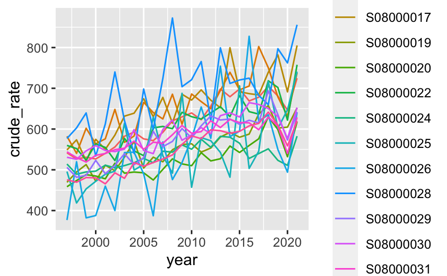

```r
# plot crude rate
incidence_hb %>%
  filter(cancer_site == "All cancer types" & sex == "All") %>%
  ggplot(aes(x = year, y = crude_rate, colour = hb)) +
  geom_line() #+
```

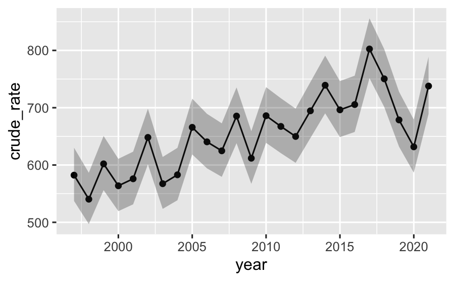

```r
  #geom_ribbon(aes(ymin = crude_rate_lower95pc_confidence_interval,
              #     ymax = crude_rate_upper95pc_confidence_interval),
              # alpha=0.3)

# plot borders with ci range
incidence_hb %>%
  filter(cancer_site == "All cancer types" & sex == "All") %>%
  filter(hb == hb_borders) %>%
  ggplot(aes(x = year, y = crude_rate)) +
  geom_line() +
  geom_point() +
  geom_ribbon(aes(ymin = crude_rate_lower95pc_confidence_interval,
                  ymax = crude_rate_upper95pc_confidence_interval),
              alpha=0.3)
```

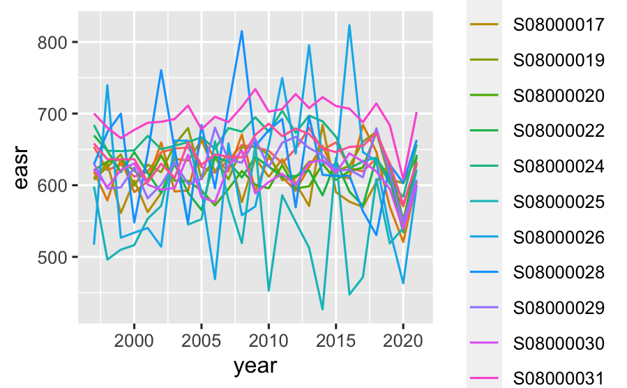

```r
# plot easr
# plot crude rate
incidence_hb %>%
  filter(cancer_site == "All cancer types" & sex == "All") %>%
  ggplot(aes(x = year, y = easr, colour = hb)) +
  geom_line() #+
```

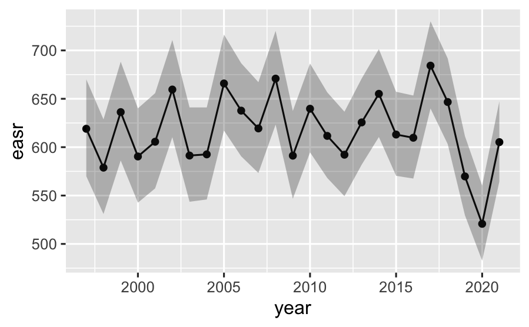

```r
  #geom_ribbon(aes(ymin = crude_rate_lower95pc_confidence_interval,
              #     ymax = crude_rate_upper95pc_confidence_interval),
              # alpha=0.3)

# plot borders with ci range
incidence_hb %>%
  filter(cancer_site == "All cancer types" & sex == "All") %>%
  filter(hb == hb_borders) %>%
  ggplot(aes(x = year, y = easr)) +
  geom_line() +
  geom_point() +
  geom_ribbon(aes(ymin = easr_lower95pc_confidence_interval,
                  ymax = easr_upper95pc_confidence_interval),
              alpha=0.3)
```

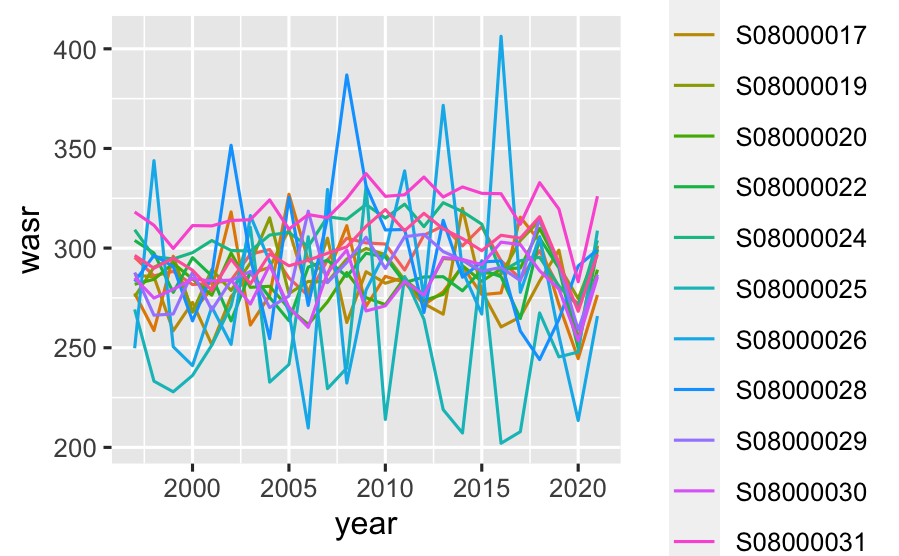

```r
# plot wasr
incidence_hb %>%
  filter(cancer_site == "All cancer types" & sex == "All") %>%
  ggplot(aes(x = year, y = wasr, colour = hb)) +
  geom_line() #+
```

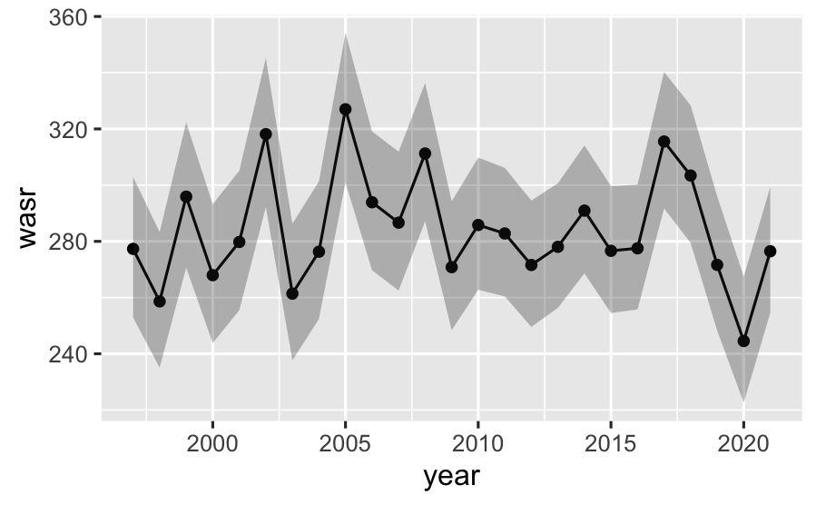

```r
  #geom_ribbon(aes(ymin = crude_rate_lower95pc_confidence_interval,
              #     ymax = crude_rate_upper95pc_confidence_interval),
              # alpha=0.3)

# plot borders with ci range
incidence_hb %>%
  filter(cancer_site == "All cancer types" & sex == "All") %>%
  filter(hb == hb_borders) %>%
  ggplot(aes(x = year, y = wasr)) +
  geom_line() +
  geom_point() +
  geom_ribbon(aes(ymin = wasr_lower95pc_confidence_interval,
                  ymax = wasr_upper95pc_confidence_interval),
              alpha=0.3)
```

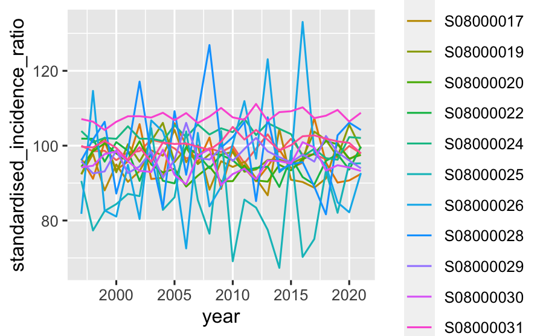

```r
# plot sir
incidence_hb %>%
  filter(cancer_site == "All cancer types" & sex == "All") %>%
  ggplot(aes(x = year, y = standardised_incidence_ratio, colour = hb)) +
  geom_line() #+
```

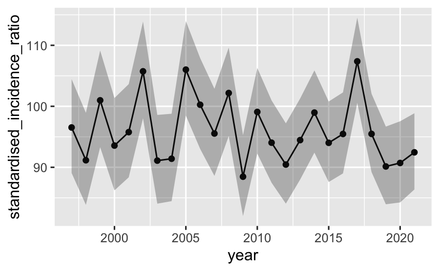

```r
  #geom_ribbon(aes(ymin = sir_lower95pc_confidence_interval,
              #     ymax = sir_upper95pc_confidence_interval),
              # alpha=0.3)

# plot borders with ci range
incidence_hb %>%
  filter(cancer_site == "All cancer types" & sex == "All") %>%
  filter(hb == hb_borders) %>%
  ggplot(aes(x = year, y = standardised_incidence_ratio)) +
  geom_line() +
  geom_point() +
  geom_ribbon(aes(ymin = sir_lower95pc_confidence_interval,
                  ymax = sir_upper95pc_confidence_interval),
              alpha=0.3)
```

### plot incidence factors for hb

look at combined 5 year data

```r
colnames(comb_5yr_incidence_hb)
```

```
 [1] "hb"
 [2] "cancer_site_icd10code"
 [3] "cancer_site"
 [4] "sex"
 [5] "sex_qf"
 [6] "year"
 [7] "incidences_age_under5"
 [8] "incidences_age5to9"
 [9] "incidences_age10to14"
[10] "incidences_age15to19"
[11] "incidences_age20to24"
[12] "incidences_age25to29"
[13] "incidences_age30to34"
[14] "incidences_age35to39"
[15] "incidences_age40to44"
```

[output cut: 44 more lines]

could pivot_longer for age?

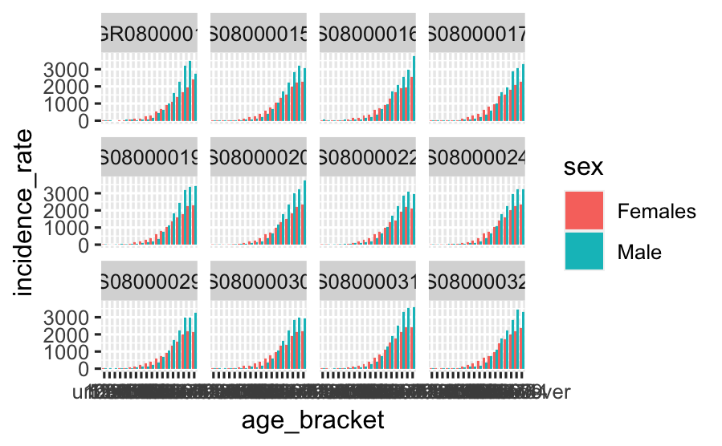

```r
# incidence_rate by age bracket, split by hb
comb_5_hb_inc_rate_age <- comb_5yr_incidence_hb %>%
  pivot_longer(cols = c(26:43),
                 names_to = "age_bracket",
               values_to = "incidence_rate") %>%
  mutate(age_bracket = str_replace(age_bracket, "^incidence_rate_age", ""),
         age_bracket = str_replace(age_bracket, "\\_", ""),
         age_bracket = factor(age_bracket,
                              levels = c(
                                "under5", "5to9", "10to14", "15to19", "20to24",
                                "25to29", "30to34", "35to39", "40to44", "45to49",
                                "50to54", "55to59", "60to64", "65to69", "70to74",
                                "75to79", "80to84", "85andover"
                              )
                                ),
         older_age = if_else(
    age_bracket %in% c("65to69", "70to74", "75to79", "80to84", "85andover"),
    "65 and over", "Under 65"))

comb_5_hb_inc_rate_age %>%
  filter(cancer_site == "All cancer types" & sex != "All") %>%
  ggplot(aes(x = age_bracket, y = incidence_rate)) +
  geom_col(aes(fill = sex), position = "dodge") +
  facet_wrap(~ hb)
```

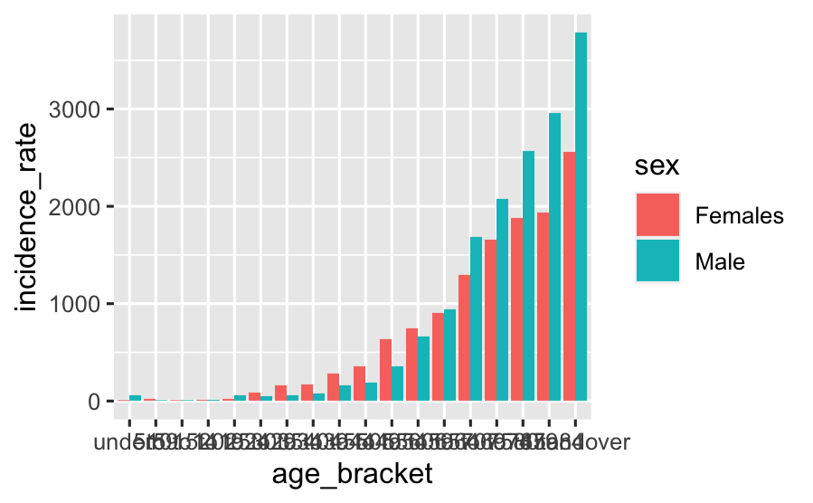

```r
comb_5_hb_inc_rate_age %>%
  filter(cancer_site == "All cancer types" & sex != "All" & hb == hb_borders) %>%
  ggplot(aes(x = age_bracket, y = incidence_rate)) +
  geom_col(aes(fill = sex), position = "dodge")
```

incidence is higher in higher age groups, and greater for males than females from age 60, and before then greater for females –> do stats on all cancers, check in diff cancer types

borders pattern looks similar to other hbs, but males in oldest age group particularly high

further analysis:

- look at 5 highest age brackets: 65 and over
- look by cancer type – note too many cancer_sites, so find most prevalent ones

```r
comb_5yr_incidence_hb %>%
  filter(sex == "All" & cancer_site != "All cancer types") %>%
  summarise(mean_easr = mean(easr, na.rm=TRUE), .by = cancer_site) %>%
  arrange(desc(mean_easr)) %>%
  slice_max(mean_easr, n = 10) %>%
  pull(cancer_site)
```

```
 [1] "Non-melanoma skin cancer"            "Basal cell carcinoma of the skin"
 [3] "Trachea, bronchus and lung"          "Breast"
 [5] "Squamous cell carcinoma of the skin" "Colorectal cancer"
 [7] "Colon"                               "Malignant melanoma of the skin"
 [9] "Head and neck"                       "Rectum and rectosigmoid junction"
```

skin cancers are the highest incidence in past 5 years (2017-2021)

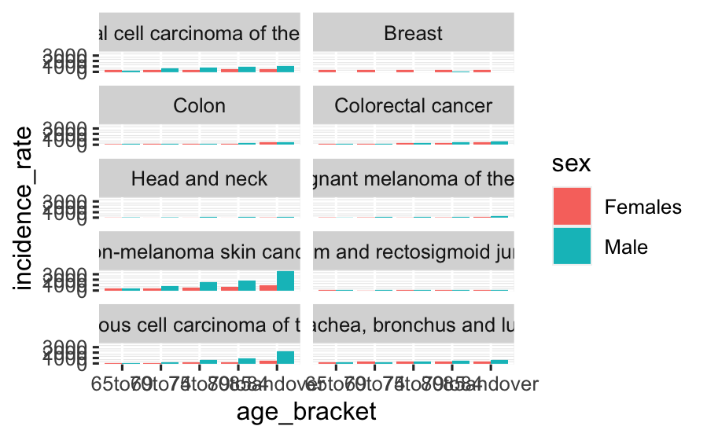

```r
comb_5_hb_inc_rate_age %>%
  filter(cancer_site %in% top_cancers_scotland & sex != "All" &
           hb == hb_borders & older_age == "65 and over") %>%
  ggplot(aes(x = age_bracket, y = incidence_rate)) +
  geom_col(aes(fill = sex), position = "dodge") +
  facet_wrap(~ cancer_site, ncol = 2)
```

cancer incidence in men 65 and over driven by skin cancer (3 types)

what about women?

[output not shown]

```r
top_cancers_scotland_females_means

top_cancers_scotland_males_means
```

| cancer_site | mean_easr |
| --- | --- |
| Non-melanoma skin cancer | 290.90125 |
| Basal cell carcinoma of the skin | 163.92963 |
| Prostate | 160.26781 |
| Squamous cell carcinoma of the skin | 123.82449 |
| Trachea, bronchus and lung | 101.94112 |
| Colorectal cancer | 86.34054 |
| Colon | 57.77002 |
| Head and neck | 32.92233 |
| Rectum and rectosigmoid junction | 28.57052 |
| Malignant melanoma of the skin | 27.50911 |

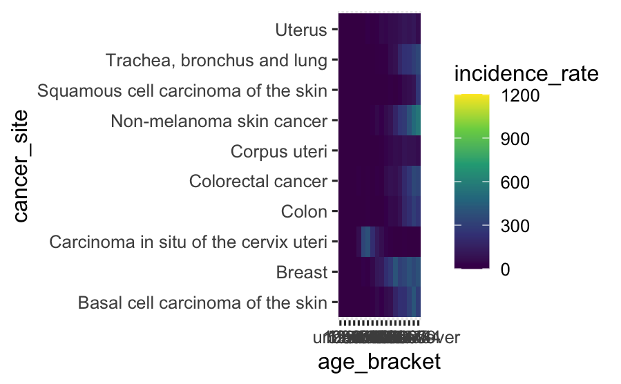

```r
comb_5_hb_inc_rate_age %>%
  filter(sex == "Females" & cancer_site %in% top_cancers_scotland_females) %>%
  ggplot(aes(age_bracket, cancer_site, fill = incidence_rate)) +
  geom_tile() +
  scale_fill_viridis_c()
```

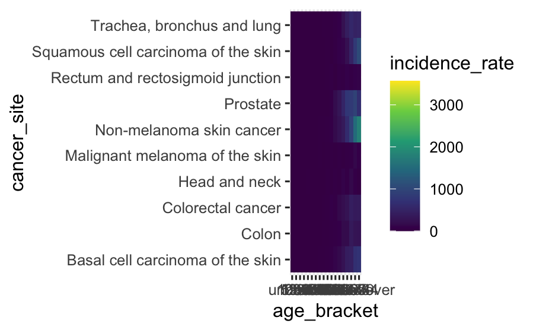

```r
comb_5_hb_inc_rate_age %>%
  filter(sex == "Male" & cancer_site %in% top_cancers_scotland_males) %>%
  ggplot(aes(age_bracket, cancer_site, fill = incidence_rate)) +
  geom_tile() +
  scale_fill_viridis_c()
```

#### cancer type by age for top ones in borders

```r
# top cancers females in borders
top_cancers_borders_females_means <- comb_5_hb_inc_rate_age %>%
  filter(hb == hb_borders &
         sex == "Females" &
           cancer_site != "All cancer types") %>%
  summarise(mean_easr = mean(easr, na.rm=TRUE), .by = cancer_site) %>%
  arrange(desc(mean_easr)) %>%
  slice_max(mean_easr, n = 10)

top_cancers_borders_females <- top_cancers_borders_females_means %>%
  pull(cancer_site)

# top cancers males in borders
top_cancers_borders_males_means <- comb_5_hb_inc_rate_age %>%
  filter(hb == hb_borders &
         sex == "Male" &
           cancer_site != "All cancer types") %>%
  summarise(mean_easr = mean(easr, na.rm=TRUE), .by = cancer_site) %>%
  arrange(desc(mean_easr)) %>%
  slice_max(mean_easr, n = 10) %>%
  mutate(cancer_site = factor(cancer_site, levels = (cancer_site)[order(cancer_site)]))


top_cancers_borders_males <- top_cancers_borders_males_means %>%
  pull(cancer_site)
```

Or use incidences in “All ages” to find top 10 by number of incidences alone

| cancer_site | incidences |
| --- | --- |
| Breast | 587 |
| Non-melanoma skin cancer | 552 |
| Basal cell carcinoma of the skin | 405 |
| Trachea, bronchus and lung | 306 |
| Colorectal cancer | 267 |
| Colon | 193 |
| Carcinoma in situ of the cervix uteri | 152 |
| Squamous cell carcinoma of the skin | 144 |
| Uterus | 119 |
| Malignant melanoma of the skin | 89 |

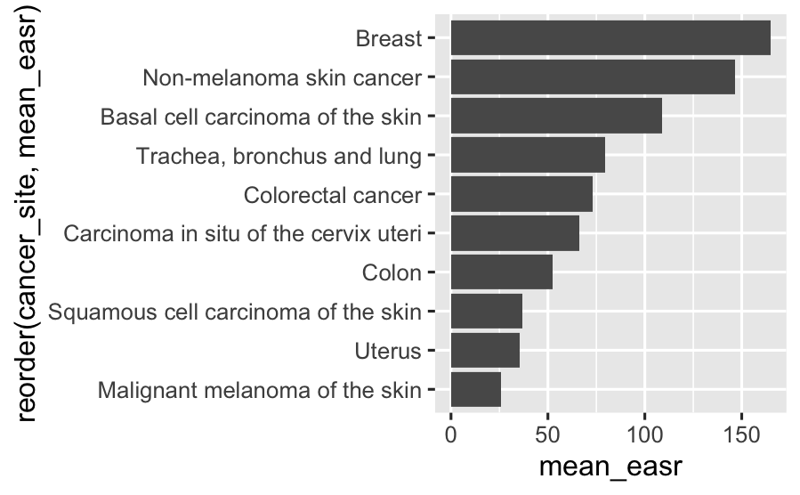

```r
top_cancers_borders_females_means %>%
  ggplot() +
  geom_col(aes(x = mean_easr, y = reorder(cancer_site, mean_easr)))
```

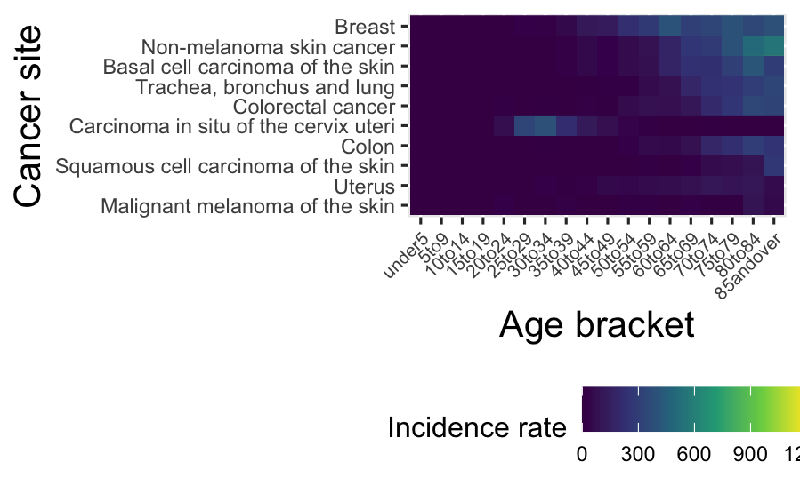

```r
comb_5_hb_inc_rate_age %>%
  filter(sex == "Females" & cancer_site %in% top_cancers_borders_females) %>%
  mutate(cancer_site = factor(cancer_site, levels = c(
    "Breast", "Non-melanoma skin cancer", "Basal cell carcinoma of the skin",
    "Trachea, bronchus and lung", "Colorectal cancer",
    "Carcinoma in situ of the cervix uteri", "Colon",
    "Squamous cell carcinoma of the skin", "Uterus", "Malignant melanoma of the skin"
  ))) %>%
  ggplot(aes(age_bracket, fct_rev(cancer_site), fill = incidence_rate)) +
  geom_tile() +
  scale_fill_viridis_c() +
  labs(x = "Age bracket", y = "Cancer site", fill = "Incidence rate") +
  theme(axis.text.y = element_text(size = 8),
        legend.text = element_text(size = 8),
        axis.text.x = element_text(angle = 45, hjust = 1, size = 7),
        axis.title = element_text(size = 14),
        legend.position = "bottom")

ggsave("tile_female_borders_inc_by_cancer_age.png", width = 15, height = 10, units = "cm")
```

Try with top 10 by total incidences (not mean easr)

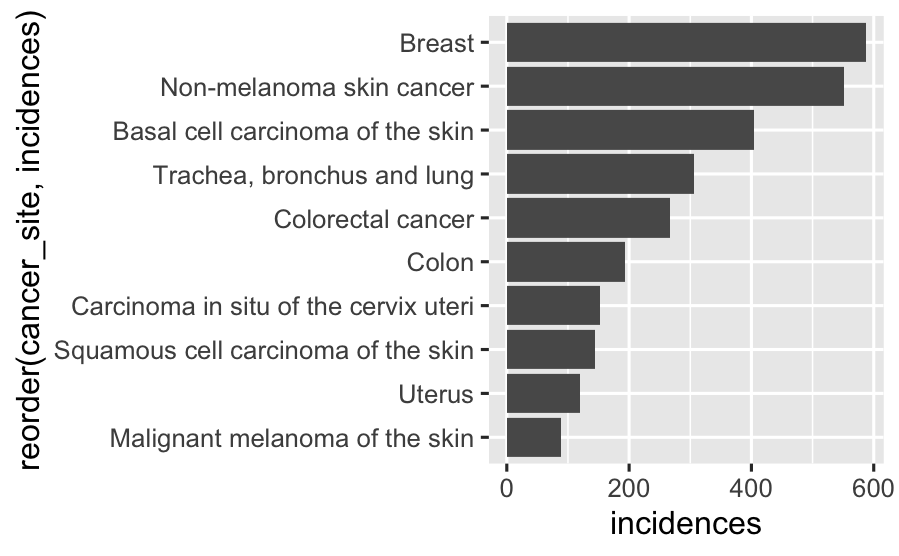

```r
top_cancers_borders_females_inc %>%
  ggplot() +
  geom_col(aes(x = incidences, y = reorder(cancer_site, incidences)))
```

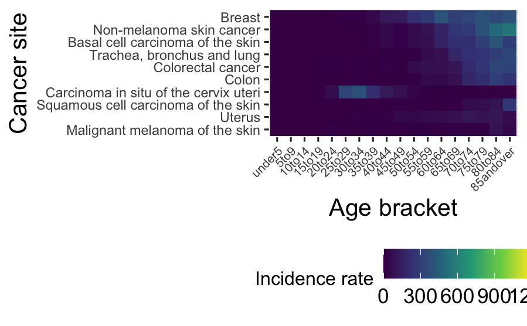

```r
comb_5_hb_inc_rate_age %>%
  filter(sex == "Females" & cancer_site %in% top_cancers_borders_females_inc_list) %>%
  mutate(cancer_site = factor(cancer_site, levels = c(
    "Breast", "Non-melanoma skin cancer",
    "Basal cell carcinoma of the skin",
    "Trachea, bronchus and lung", "Colorectal cancer",
    "Colon", "Carcinoma in situ of the cervix uteri",
    "Squamous cell carcinoma of the skin", "Uterus",
    "Malignant melanoma of the skin")
  )) %>%
  ggplot(aes(age_bracket, fct_rev(cancer_site), fill = incidence_rate)) +
  geom_tile() +
  scale_fill_viridis_c() +
  labs(x = "Age bracket", y = "Cancer site", fill = "Incidence rate") +
  theme(axis.text.y = element_text(size = 8),
        legend.text = element_text(size = 12),
        axis.text.x = element_text(angle = 45, hjust = 1, size = 7),
        axis.title = element_text(size = 14),
        legend.position = "bottom")

ggsave("tile_female_borders_inc_by_cancer_age.png", width = 15, height = 10, units = "cm")
```

[output not shown]

[output cut: 34 more lines]

```r
# make crude rate for Borders hb
```

## explore other datasets (if time)

from https://beta.isdscotland.org/find-publications-and-data/conditions-and-diseases/cancer/:

- early detection
- cancer wait times: https://publichealthscotland.scot/publications/cancer-waiting-times/cancer-waiting-times-1-january-to-31-march-2023/ – website summary report says not meeting standards (overall, including in Borders). Standards: 31 and 62 day wait times, data avail for both from https://www.opendata.nhs.scot/dataset/cancer-waiting-times.

### wait times

Consider looking at incidence v wait time trends to understand how we expect incidence trends to affect wait times (e.g. if expect increased incidence, what does wait time look like when high incidence)

```r
wait_31days <- read_csv("../data/raw_data/cwt_31_day_standard.csv") %>%
  clean_names()
wait_62days <- read_csv("../data/raw_data/cwt_31_day_standard.csv") %>%
  clean_names()
```

| year | quarter | hb | hbt | hbtqf | cancer_type | cancer_type_qf | number_of_eligible_referrals31day_standard | number_of_eligible_referrals31day_standard_qf | number_of_eligible_referrals_treated_within31days | number_of_eligible_referrals_treated_within31days_qf |
| --- | --- | --- | --- | --- | --- | --- | --- | --- | --- | --- |
| 2023 | 2023 Q1 | S08000016 | S08000016 | NA | All Cancer Types | d | 107 | p | 101 | p |
| 2023 | 2023 Q1 | S08000024 | S08000016 | NA | All Cancer Types | d | 7 | p | 6 | p |

“p” stands for provisional (expected to be finalised later): https://www.opendata.nhs.scot/dataset/statistical-qualifiers/resource/b80f9af0-b115-4245-b591-fb22775226c4

See also: https://www.isdscotland.org/Health-Topics/Waiting-Times/Cancer/Data-Quality/

note: decide whether to filter for hb or hbt – “31 day waiting standard split by health board of treatment and health board of residence as well as cancer type.

The 31 day standard is measured against the health board of first treatment (HBT)”

more about cancer data: https://www.isdscotland.org/Health-Topics/Waiting-Times/Cancer/Background/

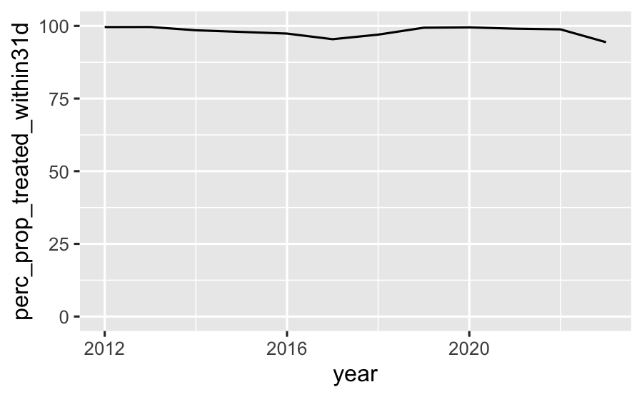

```r
wait_31days_borders_allcancers %>%
  group_by(year) %>%
  summarise(total_number_of_eligible_referrals31day_standard = sum(number_of_eligible_referrals31day_standard),
            total_number_of_eligible_referrals_treated_within31days = sum(number_of_eligible_referrals_treated_within31days),
            perc_prop_treated_within31d = 100*(total_number_of_eligible_referrals_treated_within31days/total_number_of_eligible_referrals31day_standard)) %>%
  ggplot() +
  aes(x = year, y = perc_prop_treated_within31d) +
  geom_line() +
  scale_y_continuous(limits = c(0, 100))
```

```r
NA
NA
```

could make graph of :

- borders v region v national
- 31d %, 62d %

also graph of:

wait time v incidence for all of Scotland and for borders - how does borders perform (resilience)

## check quality of dfs used

```r
# used the following dfs
# (loaded to env by running presentation_nb.Rmd)
incidence_network # easr and CIs, sex, cancer_site, year > 2011
incidence_scot
incidence_hb
comb_5yr_incidence_hb # easr (check for NAs, mean(na.rm=TRUE), incidence rate by age brackets, cancer_site, sex
```

```r
comb_5yr_incidence_hb %>%
  filter(is.na(easr)) # 0 NAs
```

| hb | cancer_site_icd10code | cancer_site | sex | sex_qf | year | incidences_age_under5 | incidences_age5to9 | incidences_age10to14 | incidences_age15to19 | incidences_age20to24 | incidences_age25to29 | incidences_age30to34 | incidences_age35to39 | incidences_age40to44 | incidences_age45to49 | incidences_age50to54 | incidences_age55to59 | incidences_age60to64 | incidences_age65to69 | incidences_age70to74 | incidences_age75to79 | incidences_age80to84 | incidences_age85and_over | incidences_all_ages | incidence_rate_age_under5 | incidence_rate_age5to9 | incidence_rate_age10to14 | incidence_rate_age15to19 | incidence_rate_age20to24 | … |
| --- | --- | --- | --- | --- | --- | --- | --- | --- | --- | --- | --- | --- | --- | --- | --- | --- | --- | --- | --- | --- | --- | --- | --- | --- | --- | --- | --- | --- | --- | --- |

```r
# used mean(easr), no NAs so no worries about this
# (not checked for normal distribution of easr though)

incidence_hb %>%
  filter(hb == hb_borders) %>% # 3400 rows
  filter(!is.na(easr_lower95pc_confidence_interval_qf) | !is.na(easr_upper95pc_confidence_interval_qf)) %>% # 2,507 NAs in CIs
  distinct(cancer_site, sex)
```

| cancer_site | sex |
| --- | --- |
| Bladder | All |
| Bladder | Male |
| Bladder | Females |
| Bone and articular cartilage | All |
| Bone and articular cartilage | Male |
| Bone and articular cartilage | Females |
| Bone and connective tissue | All |
| Bone and connective tissue | Male |
| Bone and connective tissue | Females |
| Connective tissue | All |

[output cut: 101 more lines]

```r
incidence_network %>%
  filter(region == "South East of Scotland") %>% # 3400 rows
  filter(!is.na(easr_lower95pc_confidence_interval_qf) | !is.na(easr_upper95pc_confidence_interval_qf)) %>% # 554 NAs in CIs
  distinct(cancer_site, sex)
```

| cancer_site | sex |
| --- | --- |
| Bone and articular cartilage | All |
| Bone and articular cartilage | Male |
| Bone and articular cartilage | Females |
| Bone and connective tissue | Females |
| Connective tissue | Male |
| Connective tissue | Females |
| Non-malig brain ca (incl pit.gland,cranio.duct,pineal gland) | All |
| Non-malig brain ca (incl pit.gland,cranio.duct,pineal gland) | Male |
| Non-malig brain ca (incl pit.gland,cranio.duct,pineal gland) | Females |
| All brain and CNS tumours (malignant and non-malignant) | All |

[output cut: 29 more lines]

```r
incidence_scot %>% # 3400 rows
  filter(!is.na(easr_lower95pc_confidence_interval_qf) | !is.na(easr_upper95pc_confidence_interval_qf)) %>% # 87 NAs in CIs
  distinct(cancer_site, sex)
```

| cancer_site | sex |
| --- | --- |
| Bone and articular cartilage | Male |
| Bone and articular cartilage | Females |
| Non-malig brain ca (incl pit.gland,cranio.duct,pineal gland) | All |
| Non-malig brain ca (incl pit.gland,cranio.duct,pineal gland) | Male |
| Non-malig brain ca (incl pit.gland,cranio.duct,pineal gland) | Females |
| All brain and CNS tumours (malignant and non-malignant) | All |
| All brain and CNS tumours (malignant and non-malignant) | Male |
| All brain and CNS tumours (malignant and non-malignant) | Females |
| Breast | Male |
| Carcinoma in situ of the breast | Male |

[output cut: 6 more lines]

These NAs in CIs are for diff types of cancers ~ sexes. Non are for non-melanoma skin cancer, which is what I’ve used these CIs to plot in presentation.